# Preprocessing

### 2. KPSS Test

- $H_0$ (Null Hypothesis): The series **is stationary**.
- $H_1$ (Alternative Hypothesis): The series is **not stationary**.
- **Result:** The *p-value* is **0.1** (with the warning “p-value greater than printed p-value,” implying the actual probability is even higher, likely > 0.10).
- **Conclusion:** Since the p-value is greater than 0.05, **fail to reject** $H_0$. The evidence supports the conclusion that the series is **stationary**.

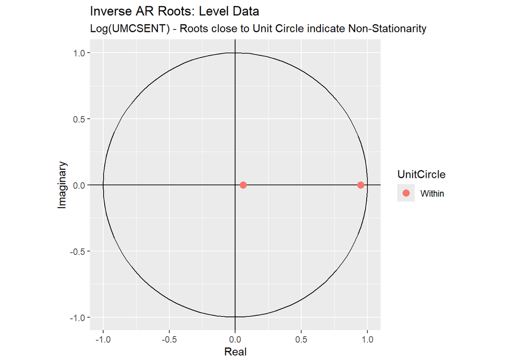

```r
# Library required for autoplot of roots
library(forecast)
library(ggplot2)
library(gridExtra) # To arrange plots side by side if installed, otherwise plot sequentially

# --- 1. Fit AR Models ---
# We fit an AR(2) model to both series to see where the roots lie.
# We force d=0 because we want to see the properties of the raw data vs the manually differenced data.

# Model on Level Data (Log UMCSENT)
model_level_check <- Arima(data_filtered$log_UMCSENT, order = c(2, 0, 0))

# Model on Differenced Data
# We use na.omit because the first observation of the difference is NA
model_diff_check <- Arima(na.omit(data_filtered$diff_log_UMCSENT), order = c(2, 0, 0))

# --- 2. Plotting ---

# Plot A: Level Data
p1 <- autoplot(model_level_check) +
  labs(title = "Inverse AR Roots: Level Data",
       subtitle = "Log(UMCSENT) - Roots close to Unit Circle indicate Non-Stationarity")

# Plot B: Differenced Data
p2 <- autoplot(model_diff_check) +
  labs(title = "Inverse AR Roots: Differenced Data",
       subtitle = "First Diff - Roots inside Unit Circle indicate Stationarity")

# Display plots
print(p1)
```

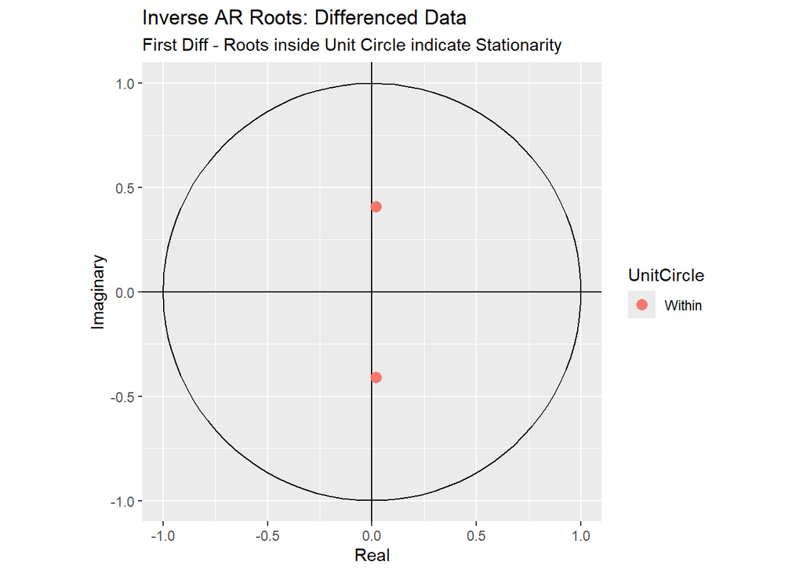

```r
print(p2)
```

### 7.2 ACF and PACF

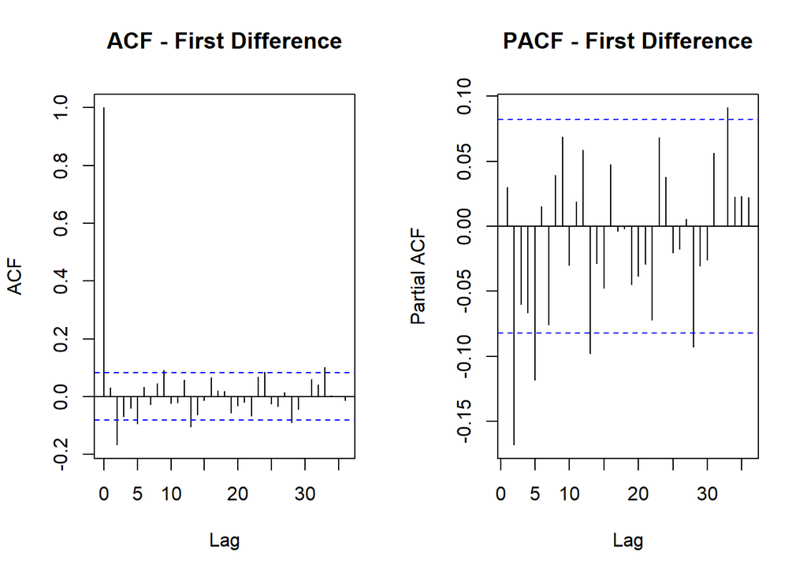

```r
# ACF and PACF of differenced data
par(mfrow = c(1, 2))

# Autocorrelation Function (per stimare q - parte MA)
acf(diff_log, main = "ACF - First Difference", lag.max = 36)

# Partial Autocorrelation Function (per stimare p - parte AR)
pacf(diff_log, main = "PACF - First Difference", lag.max = 36)
```

```r
par(mfrow = c(1, 1))

# ACF values
acf_values <- acf(diff_log, lag.max = 36, plot = FALSE)

acf_table <- data.frame(
  Lag = acf_values$lag[,,1],
  ACF = acf_values$acf[,,1]
)
print(acf_table)
```

```
##    Lag          ACF
## 1    0  1.000000000
## 2    1  0.030131616
## 3    2 -0.166843698
## 4    3 -0.069126640
## 5    4 -0.039989234
## 6    5 -0.094552614
## 7    6  0.032965653
## 8    7 -0.026355603
## 9    8  0.044842331
## 10   9  0.091401787
## 11  10 -0.024061241
## 12  11 -0.020619779
## 13  12  0.058789817
## 14  13 -0.104041274
```

[output cut: 23 more lines]

```r
# PACF values
pacf_values <- pacf(diff_log, lag.max = 36, plot = FALSE)

pacf_table <- data.frame(
  Lag = pacf_values$lag[,,1],
  PACF = pacf_values$acf[,,1]
)
print(pacf_table)
```

```
##    Lag          PACF
## 1    1  0.0301316163
## 2    2 -0.1679040552
## 3    3 -0.0599387132
## 4    4 -0.0662658252
## 5    5 -0.1179963337
## 6    6  0.0150855389
## 7    7 -0.0754417650
## 8    8  0.0391517171
## 9    9  0.0684909249
## 10  10 -0.0299858581
## 11  11  0.0190392235
## 12  12  0.0584810666
## 13  13 -0.0977196201
## 14  14 -0.0286721880
```

[output cut: 22 more lines]

### 1. General Interpretation

The most striking feature of both tables is that **Lag 1 is statistically insignificant** (approx 0.03), while **Lag 2 is significant** (approx -0.17).

- **Absence of Short-Term Memory:** The fact that Lag 1 is near zero in both ACF and PACF means the series does not depend on the immediately preceding month.
- **Lag 2 Dependency:** The significant negative spike at Lag 2 in both functions suggests a specific 2-period relationship.

Because the ACF and PACF look somewhat similar (both have a spike at Lag 2 and are otherwise quiet), it indicates a process that can be modeled effectively by either pure AR or pure MA terms, provided they reach the second lag.

### 2. Best Possible Models (Candidates)

Based on the standard identification rules (Box-Jenkins methodology), here are the top candidates:

#### **Candidate A: ARIMA(0, 1, 2)**

- **Why?** This relies on the **ACF** interpretation. The ACF shows significant activity up to Lag 2 and then largely cuts off (ignoring the minor Lag 5 noise). This suggests a Moving Average (MA) process of order $q=2$.
- **Note:** Since Lag 1 is insignificant, the model will likely estimate a very small coefficient for the first MA term ($ma1 \approx 0$) and a significant one for the second ($ma2 \approx -0.17$).

#### **Candidate B: ARIMA(2, 1, 0)**

- **Why?** This relies on the **PACF** interpretation. The PACF shows significant activity at Lag 2 and then mostly cuts off (again, barring the Lag 5 spike). This suggests an AutoRegressive (AR) process of order $p=2$.
- **Note:** Similar to the model above, this would likely result in a model where the $ar1$ coefficient is near zero, but $ar2$ is significant.

## 7.3 Model Selection (AIC/BIC Comparison)

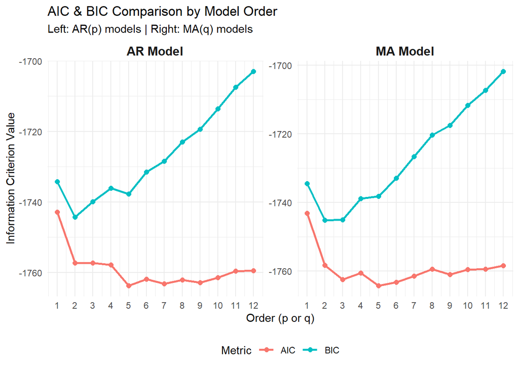

```r
library(tidyr) # Necessaria per riorganizzare i dati per il grafico

# 1. Inizializzazione del dataframe per i risultati
results <- data.frame(Order = integer(),
                      Type = character(),
                      AIC = numeric(),
                      BIC = numeric())

# 2. Calcolo dei modelli AR e MA da ordine 1 a 12
# Usiamo il dataset log_UMCSENT e impostiamo d=1 (differenza prima) nel comando Arima

for (i in 1:12) {

  # Modello AR(i): ARIMA(i, 1, 0)
  try({
    fit_ar <- Arima(data_filtered$log_UMCSENT, order = c(i, 1, 0))
    results <- rbind(results, data.frame(Order = i, Type = "AR Model", AIC = fit_ar$aic, BIC = fit_ar$bic))
  }, silent = TRUE)

  # Modello MA(i): ARIMA(0, 1, i)
  try({
    fit_ma <- Arima(data_filtered$log_UMCSENT, order = c(0, 1, i))
    results <- rbind(results, data.frame(Order = i, Type = "MA Model", AIC = fit_ma$aic, BIC = fit_ma$bic))
  }, silent = TRUE)
}

# 3. Ristrutturazione dei dati (Pivot Long)
# Trasformiamo le colonne AIC e BIC in una sola colonna "Metric" per poterle plottare come linee diverse
results_long <- pivot_longer(results, cols = c("AIC", "BIC"), names_to = "Metric", values_to = "Value")

# 4. Creazione del Grafico
ggplot(results_long, aes(x = Order, y = Value, color = Metric, group = Metric)) +
  geom_line(size = 1) +
  geom_point(size = 2) +
  # facet_wrap divide il grafico in due pannelli: uno per AR e uno per MA
  facet_wrap(~ Type, scales = "free_y") +
  scale_x_continuous(breaks = 1:12) +
  labs(title = "AIC & BIC Comparison by Model Order",
       subtitle = "Left: AR(p) models | Right: MA(q) models",
       x = "Order (p or q)",
       y = "Information Criterion Value",
       color = "Metric") +
  theme_minimal() +
  theme(
    legend.position = "bottom",
    strip.text = element_text(size = 12, face = "bold") # Formattazione dei titoli dei pannelli
  )
```

```r
# Stampa dei valori minimi per controllo numerico
cat("Lowest AIC found:\n")
```

```
## Lowest AIC found:
```

```r
print(results[which.min(results$AIC), ])
```

```
##    Order     Type       AIC       BIC
## 10     5 MA Model -1764.309 -1738.215
```

```r
cat("\nLowest BIC found:\n")
```

```
##
## Lowest BIC found:
```

```r
print(results[which.min(results$BIC), ])
```

```
##   Order     Type      AIC       BIC
## 4     2 MA Model -1758.29 -1745.243
```

## 8. Training and Test sets

```r
# split dataset into training/test
nrows <- nrow(data_filtered)
index_division <- floor(0.80 * nrows)

train <- subset(data_filtered, 1:nrows <= index_division)
test <- subset(data_filtered, 1:nrows > index_division)

cat("Training:", nrow(train), "rows\n")
```

```
## Training: 458 rows
```

```r
cat("Test:", nrow(test), "rows\n")
```

```
## Test: 115 rows
```

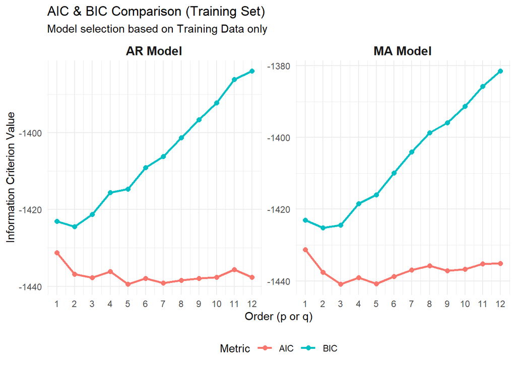

```r
library(tidyr)
library(forecast)
library(ggplot2)

# 1. Inizializzazione del dataframe per i risultati
results <- data.frame(Order = integer(),
                      Type = character(),
                      AIC = numeric(),
                      BIC = numeric())

# 2. Calcolo dei modelli AR e MA da ordine 1 a 12
# *** MODIFICA: Usiamo train$log_UMCSENT invece di data_filtered ***

for (i in 1:12) {

  # Modello AR(i): ARIMA(i, 1, 0) calcolato su TRAIN
  try({
    fit_ar <- Arima(train$log_UMCSENT, order = c(i, 1, 0))
    results <- rbind(results, data.frame(Order = i, Type = "AR Model", AIC = fit_ar$aic, BIC = fit_ar$bic))
  }, silent = TRUE)

  # Modello MA(i): ARIMA(0, 1, i) calcolato su TRAIN
  try({
    fit_ma <- Arima(train$log_UMCSENT, order = c(0, 1, i))
    results <- rbind(results, data.frame(Order = i, Type = "MA Model", AIC = fit_ma$aic, BIC = fit_ma$bic))
  }, silent = TRUE)
}

# 3. Ristrutturazione dei dati (Pivot Long)
results_long <- pivot_longer(results, cols = c("AIC", "BIC"), names_to = "Metric", values_to = "Value")

# 4. Creazione del Grafico
ggplot(results_long, aes(x = Order, y = Value, color = Metric, group = Metric)) +
  geom_line(size = 1) +
  geom_point(size = 2) +
  # facet_wrap divide il grafico in due pannelli: uno per AR e uno per MA
  facet_wrap(~ Type, scales = "free_y") +
  scale_x_continuous(breaks = 1:12) +
  labs(title = "AIC & BIC Comparison (Training Set)",
       subtitle = "Model selection based on Training Data only",
       x = "Order (p or q)",
       y = "Information Criterion Value",
       color = "Metric") +
  theme_minimal() +
  theme(
    legend.position = "bottom",
    strip.text = element_text(size = 12, face = "bold")
  )
```

```r
# Stampa dei valori minimi per controllo numerico
cat("Lowest AIC found (on Train):\n")
```

```
## Lowest AIC found (on Train):
```

```r
print(results[which.min(results$AIC), ])
```

```
##   Order     Type      AIC       BIC
## 6     3 MA Model -1440.92 -1424.421
```

```r
cat("\nLowest BIC found (on Train):\n")
```

```
##
## Lowest BIC found (on Train):
```

```r
print(results[which.min(results$BIC), ])
```

```
##   Order     Type      AIC       BIC
## 4     2 MA Model -1437.61 -1425.236
```

```r
## 9.1 Grid Search: AIC/BIC Heatmap for Mixed Models

library(ggplot2)
library(dplyr)
library(tidyr)

# 1. Impostazioni della griglia
max_p <- 5  # Massimo ordine AR da testare
max_q <- 5  # Massimo ordine MA da testare

# Dataframe vuoto per salvare i risultati
grid_results <- expand.grid(p = 0:max_p, q = 0:max_q)
grid_results$AIC <- NA
grid_results$BIC <- NA

cat("Running Grid Search for ARIMA(p,1,q)... \n")
```

```
## Running Grid Search for ARIMA(p,1,q)...
```

```r
# 2. Ciclo annidato (Nested Loop) per testare tutte le combinazioni
# Nota: Usiamo try() perché alcune combinazioni complesse potrebbero dare errore
for (i in 1:nrow(grid_results)) {

  p <- grid_results$p[i]
  q <- grid_results$q[i]

  try({
    # Addestriamo il modello sul Training Set
    model <- Arima(train$log_UMCSENT, order = c(p, 1, q))

    grid_results$AIC[i] <- model$aic
    grid_results$BIC[i] <- model$bic
  }, silent = TRUE)

  # Barra di progresso testuale
  if(i %% 5 == 0) cat(".")
}
```

```
## .......
```

```r
cat("\nGrid Search Completed.\n")
```

```
##
## Grid Search Completed.
```

[figure not shown]

```r
# 3. Preparazione dati per il grafico (Pivot Long)
# Rimuoviamo righe dove il modello ha fallito (NA)
grid_clean <- na.omit(grid_results)

grid_long <- pivot_longer(grid_clean, cols = c("AIC", "BIC"), names_to = "Metric", values_to = "Value")

# Troviamo i minimi per evidenziarli nel grafico
min_vals <- grid_long %>%
  group_by(Metric) %>%
  slice(which.min(Value))

# 4. Creazione della Heatmap
ggplot(grid_long, aes(x = factor(q), y = factor(p), fill = Value)) +
  geom_tile(color = "white") +

  # Aggiungiamo il testo con il valore arrotondato dentro ogni quadrato
  geom_text(aes(label = round(Value, 1)), color = "black", size = 2.5) +

  # Evidenziamo il modello migliore con un riquadro rosso
  geom_tile(data = min_vals, aes(x = factor(q), y = factor(p)),
            fill = NA, color = "red", size = 1.5) +

  facet_wrap(~ Metric, scales = "free") + # Due pannelli separati
  scale_fill_distiller(palette = "Spectral", direction = 1) + # Colori dal rosso (alto) al blu (basso)

  labs(title = "ARIMA(p,1,q) Grid Search",
       subtitle = "Lower values (Blue) are better. Red box indicates the minimum.",
       x = "MA Order (q)",
       y = "AR Order (p)",
       fill = "Score") +

  theme_minimal() +
  theme(panel.grid = element_blank())
```

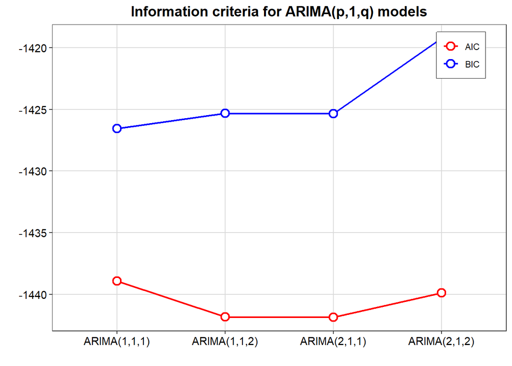

```r
## 9.2 Selected Mixed Models Comparison (Replicating the MATLAB Style Plot)

library(ggplot2)
library(tidyr)
library(forecast)

# 1. Definiamo manualmente le 4 combinazioni presenti nell'immagine
# L'immagine mostra: (1,1), (1,2), (2,1), (2,2)
# Poiché i tuoi dati richiedono differenziazione, useremo ARIMA(p, 1, q)
manual_models <- list(
  c(1, 1),
  c(1, 2),
  c(2, 1),
  c(2, 2)
)

results_mixed <- data.frame(Model = character(),
                            AIC = numeric(),
                            BIC = numeric(),
                            stringsAsFactors = FALSE)

# 2. Calcoliamo AIC e BIC per questi 4 modelli specifici
# Usiamo train$log_UMCSENT
for (ord in manual_models) {
  p <- ord[1]
  q <- ord[2]
  model_name <- paste0("ARIMA(", p, ",1,", q, ")")

  try({
    fit <- Arima(train$log_UMCSENT, order = c(p, 1, q))
    results_mixed <- rbind(results_mixed, data.frame(Model = model_name, AIC = fit$aic, BIC = fit$bic))
  }, silent = TRUE)
}

# 3. Preparazione dei dati per il grafico
# È fondamentale impostare l'ordine dei fattori per l'asse X, altrimenti R li mette in ordine alfabetico
level_order <- c("ARIMA(1,1,1)", "ARIMA(1,1,2)", "ARIMA(2,1,1)", "ARIMA(2,1,2)")
results_mixed$Model <- factor(results_mixed$Model, levels = level_order)

# Trasformiamo in formato lungo
results_long <- pivot_longer(results_mixed, cols = c("AIC", "BIC"), names_to = "Metric", values_to = "Value")

# 4. Creazione del Grafico (Stile MATLAB/Image Replication)
ggplot(results_long, aes(x = Model, y = Value, color = Metric, group = Metric)) +

  # Aggiungiamo le linee
  geom_line(size = 0.8) +

  # Aggiungiamo i punti (Shape 1 o 21 sono cerchi vuoti)
  geom_point(shape = 21, size = 3, fill = "white", stroke = 1.2) +

  # Impostiamo i colori Rosso (AIC) e Blu (BIC) come nell'immagine
  scale_color_manual(values = c("AIC" = "red", "BIC" = "blue")) +

  # Titolo e Label
  labs(title = "Information criteria for ARIMA(p,1,q) models",
       x = "",
       y = "") +

  # Tema grafico simile all'immagine (sfondo bianco con griglia)
  theme_bw() +
  theme(
    plot.title = element_text(hjust = 0.5, face = "bold", size = 14), # Titolo centrato e grassetto
    legend.position = c(0.9, 0.9), # Legenda in alto a destra all'interno del grafico
    legend.box.background = element_rect(color = "black", size = 0.5), # Riquadro attorno alla legenda
    legend.title = element_blank(), # Rimuovi titolo legenda
    panel.grid.major = element_line(color = "gray85"),
    panel.grid.minor = element_blank(),
    axis.text.x = element_text(size = 11, color = "black"),
    axis.text.y = element_text(size = 11, color = "black")
  )
```